# Visual analysis of Crop Production in Assam between 1997 & 2014

Anuraj Kashyap

2022-10-31

## Introduction

Agriculture is one of the most important primary occupation in Assam. Around 80% of the population of Assam is directly or indirectly dependent on agriculture in some way or another. so, the economy, development and many more important aspects of the people of Assam is somewhat related to agricultural factors of Assam. Crop production in Assam is depends on a large number of factors ranging from season type to Area of cultivation.

We are going to conduct a visual analysis on the Crop production in Assam, and try to convey some basic but important conclusions that may help us to understand the agricultural environment of Assam.

## Dataset Description

We are going to use the Crop Production in India Dataset for this project. Anyone willing to look into the dataset can access it through the link https://www.kaggle.com/datasets/abhinand05/crop-production-in-india?select=crop_production.csv.

The dataset consist of data for the whole India, but we are using a subset of the data containing only information about the crop production of Assam for our analysis.

Top 6 rows of the Dataset are

|  | District_Name | Crop_Year | Season | Crop | Area | Production |
| --- | --- | --- | --- | --- | --- | --- |
| 12378 | BAKSA | 2005 | Autumn | Rice | 17083 | 15415 |
| 12379 | BAKSA | 2005 | Kharif | Arhar/Tur | 191 | 115 |
| 12380 | BAKSA | 2005 | Kharif | Castor seed | 22 | 11 |
| 12381 | BAKSA | 2005 | Kharif | Cotton(lint) | 8 | 4 |
| 12382 | BAKSA | 2005 | Kharif | Jute | 382 | 3540 |
| 12383 | BAKSA | 2005 | Kharif | Maize | 179 | 134 |

The top 10 crops alongwith their mean production produced in Assam betwwen 1997 & 2014 are

| Crop | mean_production |
| --- | --- |
| Coconut | 122150506.6 |
| Paddy | 4773969.2 |
| Rice | 3988949.4 |
| Sugarcane | 1046999.7 |
| Banana | 732774.1 |
| Jute | 654974.0 |
| Potato | 612306.7 |
| Pineapple | 243554.0 |
| Orange | 148812.3 |
| Rapeseed &Mustard | 138651.3 |

It is seen that for a particular crop, the area and the production is highly correlated, the correlation matrix for Rice is shown below.

```
##                Area Production
## Area       1.000000   0.919998
## Production 0.919998   1.000000
```

## Graphical presentation

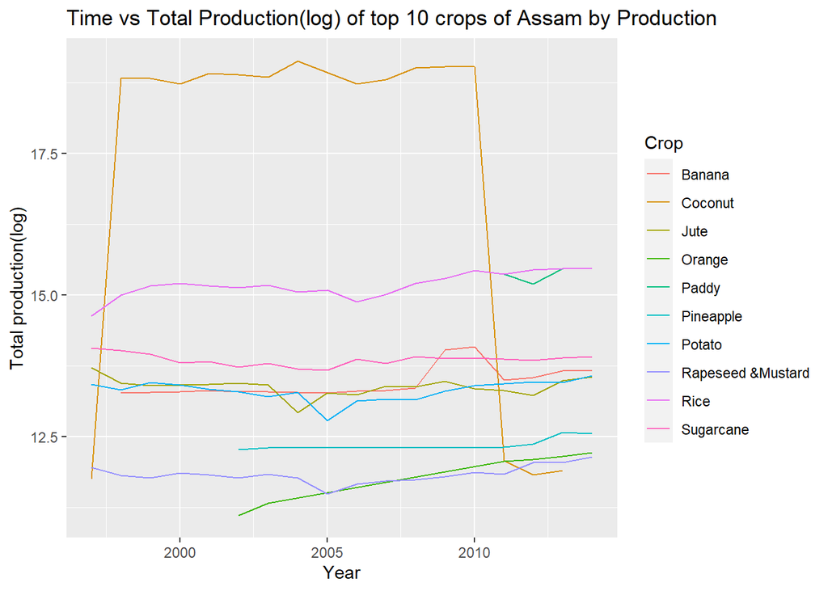

Now let us see the seasonal production of the top crops produced.

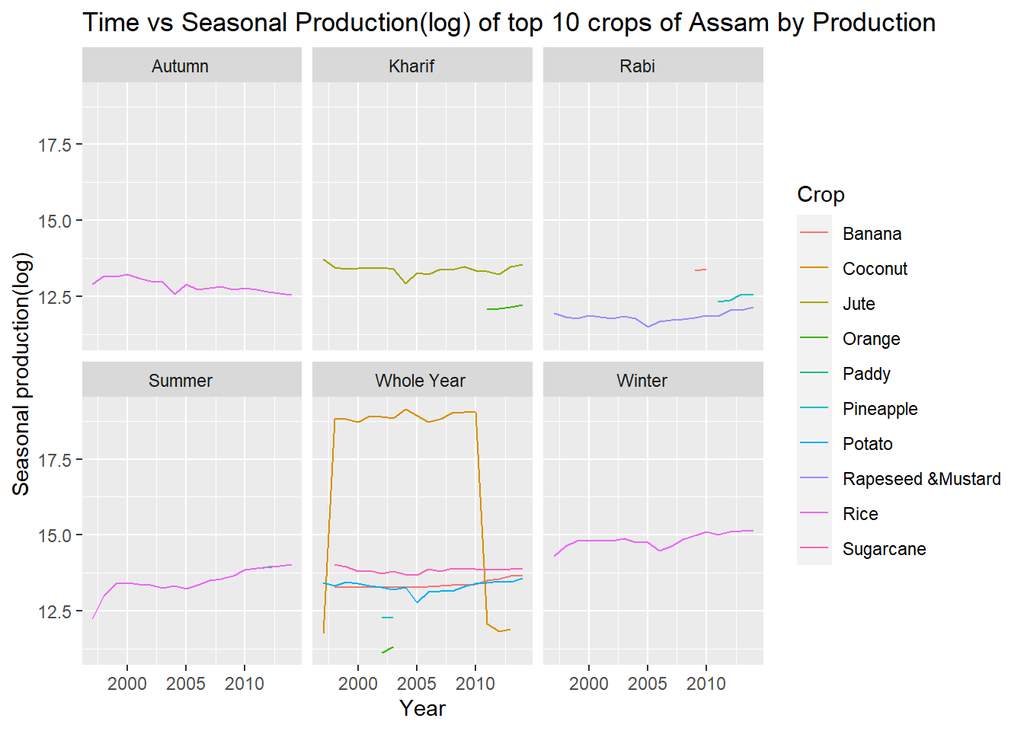

Now, we can see out of the top 10 crops only 6 of them are produced in the whole years. All other crops were produced on a seasonal basis.

Now if we look in the case of Rice, we see that it is produced in Autumn, Winter & Summer. In Winter & Summer the trend of production is increasing over the years, but in Autumn the trend of Production is decreasing.

If we look closely enough, we can see that Jute is only produced in the Kharif season and its production is more or less constant over the timeline.

We will now focus of analysis of Rice production, although analysis of other crops is also possible and anyone willing to look up on that can visit my shiny app website for the same.

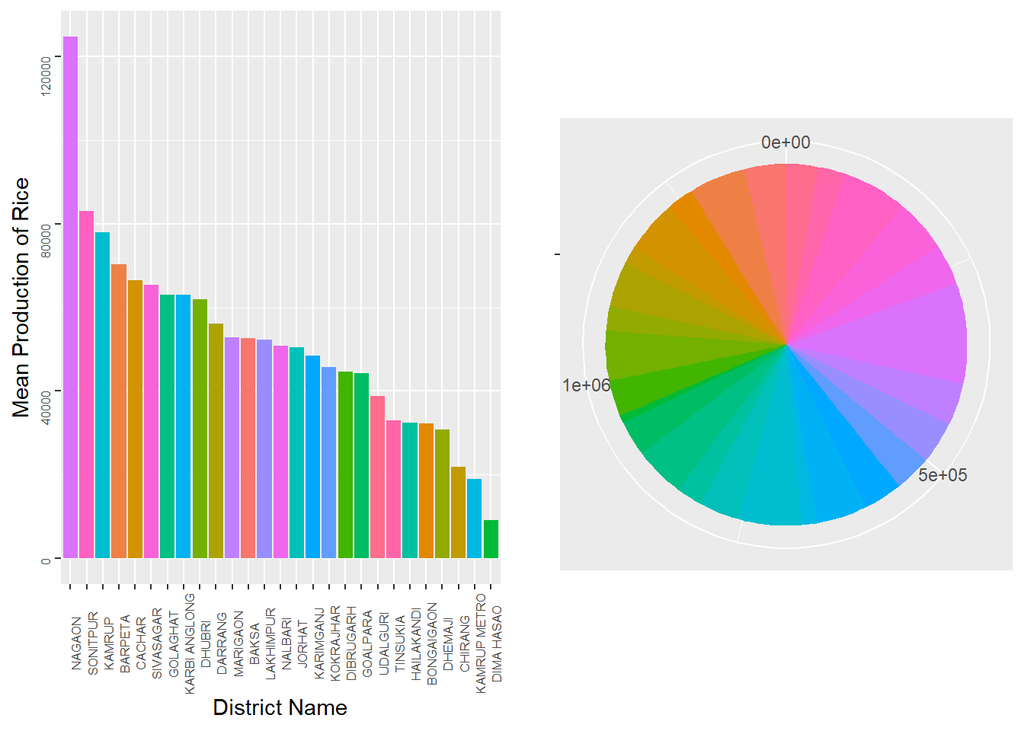

From the above graph, we can easily see that in the production of rice a large share is contributed by Nagaon as compared to other districts.

Now we can look on the trend of rice production over the years for top 10 rice producing Districts.

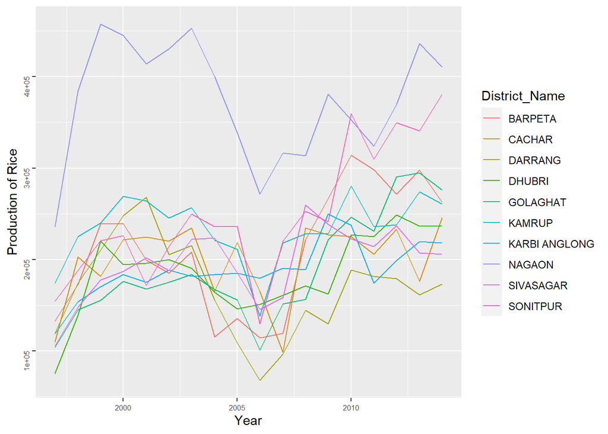

In the above plot, we have shown the trend of rice production over the years for top 10 rice producing Districts.

For more graphical presentation and analysis, please refer to my shiny app website.

## Summary of Analysis

#I have covered most of the basic visual analysis possible for the data. For further analysis and graphical presentation of the data, please go to my shiny app website.

## Conclusion

We have tried our level best to conduct a visual analysis on Crop Production in Assam and provide some important conclusions on it. The data we used is publically available and we assumed it to be correct upto a certain level while making important conclusions for the project.